# DS_CA7_810100194_810100084_810100272

## Label generation by llm(Phi-3)

```
Fitting 5 folds for each of 27 candidates, totalling 135 fits
```

```
Best Hyperparameters:  {'bootstrap': True, 'max_depth': 5, 'max_features': 'log2', 'n_estimators': 200}
```

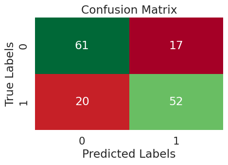

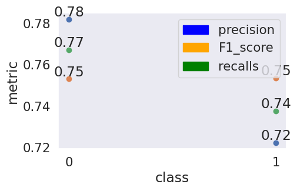

```
Precision: 0.78
Recall: 0.75
F1 Score: 0.77
Accurcy: 0.75
micro average: 1.13
weighted_average: 0.7524421249832731
macro average: 0.7524421249832731
accuract: 0.7533333333333333
              precision    recall  f1-score   support

           0       0.75      0.78      0.77        78
           1       0.75      0.72      0.74        72

    accuracy                           0.75       150
   macro avg       0.75      0.75      0.75       150
weighted avg       0.75      0.75      0.75       150
```

```python
import numpy as np
from sklearn.ensemble import RandomForestClassifier
from sklearn.model_selection import GridSearchCV
def propagate_labels_llm(labeled_embeddings, labeled_labels, unlabeled_embeddings):
    return labels_aug_df

propagated_labels = propagate_labels_llm(train_reduced, train_df['label'], unlabeled_reduced)
unlabeled_df['label'] = propagated_labels

combined_df = pd.concat([train_df, unlabeled_df], ignore_index=True)

param_grid = {
    'n_estimators': [50, 100, 200],
    'max_features': ['auto', 'sqrt', 'log2'],
    'max_depth': [5, 10 ,20],
    'bootstrap': [True]
}

classifier = RandomForestClassifier(random_state=42)
grid_search = GridSearchCV(estimator=classifier, param_grid=param_grid,
                           cv=5, n_jobs=-1, verbose=2)

combined_data = np.vstack((train_reduced, unlabeled_reduced))
grid_search.fit(combined_data, combined_df['label'])
best_classifier = grid_search.best_estimator_
test_predictions = best_classifier.predict(test_reduced)
print("Best Hyperparameters: ", grid_search.best_params_)

scoring(make_confusion_matrix(test_df['label'], test_predictions))
print(classification_report(test_df['label'], test_predictions))
```

Grdient boosting by llm labeled samples and labeled sample.

```python
classifier = GradientBoostingClassifier(random_state=42)

param_grid = {
    'n_estimators': [200],
    'learning_rate': [0.2],
    'max_depth': [5]
}

grid_search = GridSearchCV(classifier, param_grid, cv=5, scoring='precision')
grid_search.fit(combined_data, combined_df['label'])


best_classifier = grid_search.best_estimator_


best_classifier.fit(combined_data, combined_df['label'])


y_pred = best_classifier.predict(test_reduced)
```

```
GradientBoostingClassifier(learning_rate=0.2, max_depth=5, n_estimators=200,
                           random_state=42)
              precision    recall  f1-score   support

     Class 0       0.76      0.78      0.77        78
     Class 1       0.76      0.74      0.75        72

    accuracy                           0.76       150
   macro avg       0.76      0.76      0.76       150
weighted avg       0.76      0.76      0.76       150
```

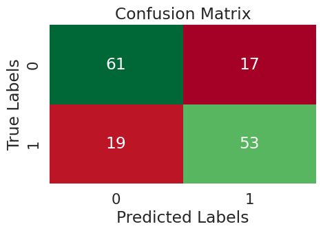

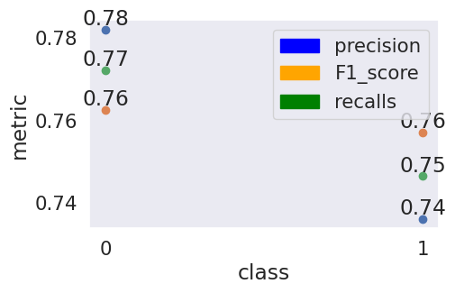

```
Precision: 0.78
Recall: 0.76
F1 Score: 0.77
Accurcy: 0.76
micro average: 1.1400000000000001
weighted_average: 0.7593153859868069
macro average: 0.7593153859868069
accuract: 0.76
```

```python
# Evaluate
print(best_classifier)
print(classification_report(test_df['label'], y_pred, target_names=["Class 0", "Class 1"]))
cm = make_confusion_matrix(test_df['label'], y_pred)
scoring(cm)
```

Gradientboosting Just By labeled data

```python
import numpy as np
import matplotlib.pyplot as plt
import seaborn as sns
from sklearn.decomposition import PCA
from sklearn.ensemble import RandomForestClassifier
from sklearn.metrics import accuracy_score, precision_score, recall_score, confusion_matrix
from sklearn.model_selection import GridSearchCV

# Assuming train_df and test_df are your datasets
X_train = np.array(train_df['embedding'].tolist())
y_train = train_df['label'].values
X_test = np.array(test_df['embedding'].tolist())
y_test = test_df['label'].values

# Initialize PCA and RandomForestClassifier
pca = PCA(n_components=150)
rf_model = RandomForestClassifier(random_state=0)

# Apply PCA
X_train_pca = pca.fit_transform(X_train)
X_test_pca = pca.transform(X_test)

# Initialize GridSearchCV
grid_search = GridSearchCV(estimator=rf_model, param_grid=param_grid, cv=5, n_jobs=-1, verbose=2)

# Fit GridSearchCV to the data
# grid_search.fit(X_train_pca, y_train)
```

```python
classifier = GradientBoostingClassifier(random_state=42)

param_grid = {
    'n_estimators': [200],
    'learning_rate': [0.2],
    'max_depth': [5]
}

grid_search = GridSearchCV(classifier, param_grid, cv=5, scoring='precision')
grid_search.fit(X_train_pca, y_train)


best_classifier = grid_search.best_estimator_


best_classifier.fit(X_train_pca, y_train)


y_pred = best_classifier.predict(X_test_pca)
```

```
              precision    recall  f1-score   support

     Class 0       0.65      0.60      0.63        78
     Class 1       0.60      0.65      0.63        72

    accuracy                           0.63       150
   macro avg       0.63      0.63      0.63       150
weighted avg       0.63      0.63      0.63       150
```

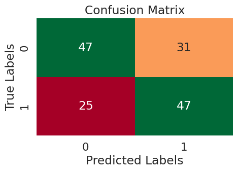

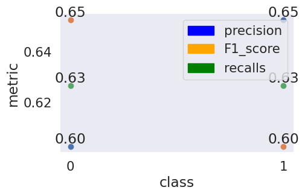

```
Precision: 0.60
Recall: 0.65
F1 Score: 0.63
Accurcy: 0.63
micro average: 0.9400000000000001
weighted_average: 0.6266666666666667
macro average: 0.6266666666666667
accuract: 0.6266666666666667
```

```python
print(classification_report(y_test, y_pred, target_names=["Class 0", "Class 1"]))
cm = make_confusion_matrix(y_test, y_pred)
scoring(cm)
```

# Questions

## Question 1

### Semi-Supervised Learning Overview

Semi-supervised learning is a machine learning approach that utilizes both labeled and unlabeled data. Typically, the amount of labeled data is small compared to the vast amount of unlabeled data. The goal is to leverage the unlabeled data to improve the learning process and the performance of the model. This approach is particularly useful in scenarios where labeling data is expensive or time-consuming.

### Selecting Data for Manual Labeling

The selection of a proportion of data for manual labeling in a semi-supervised learning context is a critical step. The choice of which data points to label can significantly impact the performance of the model. Here are several strategies and factors to consider:

1. **Random Sampling**:
   - **Description**: Randomly select a subset of data for labeling.
   - **Pros**: Simple to implement and ensures a representative sample if the data is evenly distributed.
   - **Cons**: May not be efficient if the data distribution is imbalanced or if the model struggles with certain types of examples.
2. **Uncertainty Sampling**:
   - **Description**: Label the data points where the model is most uncertain. This can be measured by metrics such as entropy, margin sampling, or least confidence.
   - **Pros**: Focuses labeling efforts on the most ambiguous cases, potentially leading to more informative data for training.
   - **Cons**: Requires an initial model to estimate uncertainty, and might lead to over-sampling of outliers.
3. **Diversity Sampling**:
   - **Description**: Select a diverse set of data points that cover the entire feature space.
   - **Pros**: Ensures that the labeled data captures a broad spectrum of the data distribution.
   - **Cons**: Can be complex to implement and requires understanding of the data's distribution in the feature space.
4. **Cluster-Based Sampling**:
   - **Description**: Use clustering algorithms to group similar data points and select representatives from each cluster.
   - **Pros**: Ensures that different regions of the data distribution are represented in the labeled set.
   - **Cons**: Depends on the quality of the clustering, which might not always reflect the true structure of the data.
5. **Active Learning**:
   - **Description**: Iteratively select data points to label based on the model’s performance and feedback loop. The model actively queries for labels of the most informative examples.
   - **Pros**: Highly adaptive and focuses on improving model performance with each iteration.
   - **Cons**: Can be computationally intensive and requires an initial model and repeated interactions.

### Factors Influencing the Choice of Data for Labeling

1. **Data Distribution and Imbalance**:
   - If the data is imbalanced (e.g., rare events or minority classes), random sampling might miss critical examples. In such cases, strategies like uncertainty or diversity sampling can help ensure that the labeled data captures important variations.
2. **Model Performance and Uncertainty**:
   - Understanding where the model performs poorly can guide the selection of data for labeling. Focusing on uncertain predictions can help improve the model’s understanding of complex or ambiguous examples.
3. **Feature Space Coverage**:
   - Ensuring that the labeled data covers the entire feature space helps in building a robust model. Techniques like diversity sampling or cluster-based sampling are useful in achieving this.
4. **Computational Resources**:
   - The complexity and cost of different sampling strategies should be considered. While methods like active learning can provide significant benefits, they may require more computational resources and time.
5. **Domain Knowledge**:
   - Expert knowledge about the data and the problem domain can be invaluable in guiding the selection process. Experts can identify critical examples or regions in the data that require attention.

### Conclusion

In semi-supervised learning, the choice of which data to label is crucial. It significantly affects the efficiency of the labeling process and the ultimate performance of the model. Depending on the nature of the data and the resources available, different strategies like random sampling, uncertainty sampling, diversity sampling, cluster-based sampling, or active learning can be employed. Each has its advantages and trade-offs, and often, a combination of methods might be the most effective approach.

## Question 2:

WE have explained in the code

## Question 3:

### Limitations of Label Propagation Methods

Label propagation is a semi-supervised learning technique that spreads labels from labeled to unlabeled data through a graph representing the data’s structure. While useful, label propagation methods have several limitations:

1. **Scalability Issues**:
   - **Description**: Label propagation methods can struggle with large datasets due to the computational complexity of constructing and processing large graphs.
   - **Impact**: For massive datasets, the time and memory required to build and process the graph can be prohibitive.
2. **Graph Construction Sensitivity**:
   - **Description**: The effectiveness of label propagation heavily depends on how the graph is constructed. Poorly chosen similarity measures or graph structures can lead to inaccurate propagation.
   - **Impact**: If the graph does not accurately reflect the true relationships between data points, the propagated labels may be incorrect or biased.
3. **Homophily Assumption**:
   - **Description**: Label propagation assumes that connected nodes in the graph are likely to share the same label (homophily). However, this assumption may not hold in all datasets, especially in those with high heterophily (where connected nodes often have different labels).
   - **Impact**: In cases of heterophily, label propagation can lead to poor performance, as it fails to correctly propagate labels across differing nodes.
4. **Local Minima and Propagation Stability**:
   - **Description**: The propagation process can get stuck in local minima, especially in cases with complex label distributions or when the labeled data is sparsely distributed.
   - **Impact**: This can result in suboptimal labeling where some regions of the graph are incorrectly or inconsistently labeled.
5. **Propagation Delay and Uncertainty**:
   - **Description**: Labels may take multiple iterations to propagate through the graph, which can introduce delays and uncertainty in the final labeling.
   - **Impact**: Slow convergence and uncertainty in early stages can hinder real-time applications and make the approach less practical for dynamic datasets.
6. **Sensitivity to Initial Labeled Data**:
   - **Description**: The initial set of labeled data can have a significant impact on the final propagated labels. If the initial labeled set is not representative, the propagated labels might be biased.
   - **Impact**: This can lead to an uneven spread of labels and poor generalization in the model.

### Overcoming Limitations with Large Language Models (LLMs)

Large Language Models (LLMs), such as GPT-4 and similar architectures, can address many of the limitations of traditional label propagation methods through their sophisticated understanding of data and contextual relationships. Here’s how LLMs can be more effective:

1. **Handling Scalability**:
   - **LLM Advantage**: LLMs are designed to process large volumes of data efficiently. They leverage parallel processing and sophisticated architectures that allow them to scale with data size more effectively than graph-based methods.
   - **Effectiveness**: This makes LLMs suitable for tasks involving massive datasets where label propagation methods may struggle.
2. **Reducing Sensitivity to Graph Construction**:
   - **LLM Advantage**: LLMs do not rely on explicitly constructed graphs; instead, they capture relationships directly from the data through their training on diverse and extensive datasets.
   - **Effectiveness**: This mitigates issues arising from poor graph construction or inappropriate similarity measures, leading to more robust performance across different data types.
3. **Addressing Homophily and Heterophily**:
   - **LLM Advantage**: LLMs can understand nuanced and complex relationships between data points, beyond simple connectivity. They can model both homophilous and heterophilous relationships more effectively.
   - **Effectiveness**: This ability allows LLMs to handle datasets where traditional label propagation methods fail due to incorrect assumptions about node relationships.
4. **Mitigating Local Minima Issues**:
   - **LLM Advantage**: LLMs use optimization techniques that are less prone to getting stuck in local minima. Their training methods and architectures allow them to explore more complex decision boundaries.
   - **Effectiveness**: This results in more stable and accurate predictions even in challenging data environments.
5. **Faster Convergence and Reduced Uncertainty**:
   - **LLM Advantage**: LLMs can provide immediate predictions without the need for iterative propagation. They can infer labels based on contextual understanding from their pre-training.
   - **Effectiveness**: This leads to faster labeling and more reliable predictions, making LLMs suitable for applications requiring timely results.
6. **Robustness to Initial Labeled Data**:
   - **LLM Advantage**: LLMs utilize transfer learning and fine-tuning, allowing them to adapt to specific tasks with relatively small labeled datasets. They can generalize better from limited initial labels.
   - **Effectiveness**: This reduces the dependency on the representativeness of the initial labeled data, as LLMs leverage their extensive pre-trained knowledge.

### Conclusion

Large Language Models offer several advantages over traditional label propagation methods in semi-supervised learning. They address key limitations such as scalability, sensitivity to graph construction, and the reliance on homophily. By capturing complex relationships and providing faster, more reliable predictions, LLMs can significantly enhance the effectiveness of semi-supervised learning tasks. Their ability to handle large datasets, model nuanced interactions, and generalize from limited labeled data makes them a powerful tool for overcoming the challenges associated with label propagation methods.

## Question 4:

### History and Evolution of Language Models

Language models have a rich history, evolving from simple statistical methods to sophisticated deep learning architectures. Here’s a timeline of key developments in the field:

1. **1950s-1960s: Early Statistical Models**:
   - **Initial Concepts**: The concept of n-grams was introduced, which involves predicting the next word in a sequence based on the previous n-1 words. This approach laid the foundation for statistical language modeling.
   - **Markov Models**: Early language models were based on Markov chains, assuming that the probability of a word depends only on the previous word(s).
2. **1980s: Rule-Based and Statistical Methods**:
   - **Rule-Based Systems**: Systems like ELIZA used pre-defined rules to generate language, but lacked flexibility and robustness.
   - **Backoff Models**: Techniques like Katz’s back-off model improved the handling of rare words by backing off to lower-order n-grams.
3. **1990s: Probabilistic Models and the Rise of NLP**:
   - **Introduction of Hidden Markov Models (HMMs)**: HMMs became popular for tasks like speech recognition, where they model sequences probabilistically.
   - **Introduction of Maximum Entropy Models**: These models provided a way to combine multiple sources of information in predicting words or tags.
4. **2000s: The Era of Neural Networks**:
   - **Neural Language Models**: Bengio et al. (2003) introduced neural network-based language models that learn word embeddings and predict words based on distributed representations, overcoming the limitations of traditional n-gram models.
   - **Recurrent Neural Networks (RNNs)**: RNNs, and later LSTM (Long Short-Term Memory) networks, allowed modeling of longer contexts by maintaining a memory of previous inputs in sequences.
5. **2010s: Breakthroughs with Deep Learning**:
   - **Sequence-to-Sequence Models**: Introduced by Sutskever et al. (2014), these models enabled tasks like machine translation by mapping input sequences to output sequences using RNNs.
   - **Attention Mechanism**: Bahdanau et al. (2015) introduced attention mechanisms, allowing models to focus on relevant parts of the input sequence, improving translation and other tasks.
   - **Transformers**: Vaswani et al. (2017) introduced the Transformer architecture, which uses self-attention mechanisms and discards recurrent structures. This led to more efficient and scalable models.
6. **Late 2010s-2020s: Emergence of Large Language Models (LLMs)**:
   - **BERT (Bidirectional Encoder Representations from Transformers)**: Introduced by Devlin et al. (2018), BERT uses bidirectional training and revolutionized many NLP tasks by understanding context from both directions in a text.
   - **GPT (Generative Pre-trained Transformer)**: Starting with GPT-1 by OpenAI, and followed by GPT-2 and GPT-3, these models demonstrated the power of large-scale pre-training followed by fine-tuning for specific tasks.
   - **T5 (Text-to-Text Transfer Transformer)**: Raffel et al. (2019) proposed treating all NLP tasks as text-to-text problems, enabling the use of a single model for a wide variety of tasks.
   - **GPT-3 and Beyond**: GPT-3 (2020) with 175 billion parameters, showcased the capabilities of LLMs in generating coherent and contextually relevant text, pushing the boundaries of what language models can achieve.

### How Language Models Work

Language models (LMs) are designed to predict the likelihood of a sequence of words. They can generate text, understand context, and perform various NLP tasks. Here’s a simplified explanation of their operation:

1. **Training Phase**:
   - **Data**: LMs are trained on large corpora of text data.
   - **Objective**: The primary objective is to learn the probability distribution of sequences of words. For example, given a sequence of words, the model predicts the next word.
   - **Model Architecture**: Different architectures (e.g., RNNs, LSTMs, Transformers) process sequences and capture dependencies between words. Transformers, in particular, use self-attention mechanisms to weigh the relevance of each word in the context of the sequence.
2. **Inference Phase**:
   - **Text Generation**: Given a prompt, the model generates text by sampling from the learned probability distribution, word by word.
   - **Context Understanding**: Models like BERT analyze entire sentences to understand context and provide relevant predictions or classifications.
   - **Task Adaptation**: Through fine-tuning, models can be adapted to specific tasks like translation, summarization, or question answering.

### Advantages of Language Models (Especially LLMs)

Large Language Models (LLMs) like GPT-4 and BERT offer a range of powerful advantages that have transformed the field of Natural Language Processing (NLP). Below, we explore these advantages in detail:

#### 1. Versatility and Adaptability

- **Multi-task Learning**: LLMs can be fine-tuned or used as they are for a wide variety of tasks without needing task-specific architectures. For example, GPT-3 can handle tasks ranging from answering questions and generating text to translating languages and summarizing content.
- **Transfer Learning**: Pre-trained LLMs can be adapted to specific tasks with relatively small amounts of additional training data. This capability makes them highly versatile and useful across different domains and applications.

#### 2. Deep Contextual Understanding

- **Comprehensive Context Grasp**: LLMs like BERT and GPT-4 use advanced architectures that allow them to understand context from entire sentences or documents, capturing relationships between words that are far apart in the text. This leads to better comprehension and more coherent responses.
- **Handling Ambiguities**: By considering context from both directions (as in BERT’s bidirectional approach), LLMs can resolve ambiguities in language and provide more accurate interpretations and predictions.

#### 3. High-Quality Text Generation

- **Fluency and Coherence**: LLMs generate text that is not only grammatically correct but also contextually coherent and fluent. This makes them suitable for applications like content creation, chatbots, and virtual assistants.
- **Diversity in Output**: They can generate diverse outputs based on the same input prompt, which is beneficial for creative writing, brainstorming, and generating multiple versions of content.

#### 4. Scalability and Pre-trained Knowledge

- **Leverage Large-Scale Data**: LLMs are trained on vast corpora of text, enabling them to encode extensive world knowledge and language patterns. This extensive pre-training allows them to perform well even on tasks they haven't explicitly been trained for.
- **Handling Varied Inputs**: Their ability to process and understand a wide range of input types (e.g., various dialects, languages, and informal text) makes them adaptable to different user needs and applications.

#### 5. Reduced Need for Extensive Task-Specific Data

- **Few-Shot Learning**: LLMs can perform well on new tasks with little to no task-specific data through few-shot or zero-shot learning. This is particularly advantageous when labeled data is scarce or expensive to obtain.
- **Generalization**: They generalize well across different tasks and domains due to their training on diverse datasets, which reduces the need for extensive fine-tuning on new tasks.

#### 6. Efficiency in Development

- **Faster Deployment**: Using pre-trained LLMs reduces the time and resources required to develop and deploy NLP systems. This accelerates the development cycle and lowers the barrier to entry for implementing advanced language processing capabilities.
- **Streamlined Model Maintenance**: Maintaining a single, powerful LLM for multiple tasks simplifies the development and operational overhead compared to managing numerous specialized models.

#### 7. Enhanced Interaction and User Experience

- **Natural Language Understanding**: LLMs improve the interaction between humans and machines by understanding and responding in natural language. This leads to more intuitive and user-friendly applications in areas like customer service, personal assistants, and education.
- **Personalization**: They can be fine-tuned to adapt to individual user preferences and histories, providing more personalized and relevant responses in applications like recommendation systems and personalized content delivery.

### Conclusion

Large Language Models (LLMs) offer transformative advantages across a range of applications due to their versatility, deep contextual understanding, and ability to generate high-quality, coherent text. They significantly reduce the need for extensive task-specific data and enable faster, more efficient development of NLP systems. Despite their challenges, the benefits they bring to natural language understanding and generation are unparalleled, making them a cornerstone in modern AI and NLP advancements.

### Addressing Limitations of Large Language Models (LLMs)

While LLMs have significant potential, mitigating their limitations is crucial to maximizing their benefits and minimizing risks. Here are several strategies and ongoing research directions aimed at addressing the challenges associated with LLMs:

1. **Resource Efficiency and Environmental Impact**:
   - **Efficient Architectures**: Research into more efficient model architectures, like distillation techniques and pruning methods, aims to reduce the computational resources needed without sacrificing performance. Examples include the DistilBERT and TinyBERT models, which are smaller and faster while maintaining competitive accuracy.
   - **Hardware Advances**: The development of specialized hardware, such as TPUs (Tensor Processing Units) and more energy-efficient GPUs, can also help reduce the energy consumption associated with training and deploying LLMs.
   - **Sustainable AI Practices**: Initiatives like carbon offsetting and optimizing energy usage during training are being explored to mitigate the environmental impact of LLMs.
2. **Bias Mitigation and Ethical AI**:
   - **Bias Detection and Correction**: Techniques are being developed to identify and correct biases in training data and model outputs. Methods like adversarial training, fairness constraints, and post-processing adjustments are being explored.
   - **Diverse Training Data**: Using more diverse and representative training data can help reduce the risk of bias in LLMs. Efforts to curate balanced datasets that reflect a wide range of perspectives and contexts are ongoing.
   - **Ethical Guidelines and Policies**: Establishing robust ethical guidelines and policies for the deployment of LLMs is essential to ensure responsible use. This includes setting standards for content moderation, transparency, and accountability.
3. **Interpretability and Explainability**:
   - **Model Explainability Tools**: Tools and techniques to interpret and explain LLM decisions are under development. Examples include SHAP (SHapley Additive exPlanations), LIME (Local Interpretable Model-agnostic Explanations), and attention visualization techniques that highlight how models focus on different parts of the input.
   - **Interactive Interfaces**: Providing interactive interfaces that allow users to explore and understand the model's behavior can enhance transparency. These interfaces can help users see how changes in input affect the output.
4. **Control and Safety Mechanisms**:
   - **Controlled Generation**: Research into controlled text generation aims to give users more precise control over the content and style of LLM outputs. Techniques such as reinforcement learning with human feedback (RLHF) and prompt tuning are being explored to achieve this.
   - **Content Moderation**: Implementing robust content moderation and filtering mechanisms can help prevent the generation of harmful or inappropriate content. This includes using pre-trained classifiers to detect and filter out problematic outputs.
   - **Safety Protocols**: Developing safety protocols and guardrails for deploying LLMs in critical or sensitive applications is vital. This includes setting up monitoring systems to detect and respond to unsafe behavior in real-time.
5. **Generalization and Robustness**:
   - **Out-of-Distribution Handling**: Research into improving the generalization capabilities of LLMs involves training on more diverse datasets and developing models that can better handle out-of-distribution inputs. Techniques like meta-learning and domain adaptation are being explored to address these challenges.
   - **Robust Prompt Design**: Improving the robustness of LLMs to different prompts involves designing prompts that are less sensitive to variations and can reliably produce the desired outputs. Prompt engineering and few-shot learning approaches are being actively researched in this area.

### Future Directions in Language Modeling

The future of language modeling is likely to involve several exciting directions, driven by ongoing research and technological advancements:

1. **Multimodal Models**:
   - **Integration of Multiple Modalities**: Future models are expected to integrate text with other data types such as images, audio, and video. This multimodal approach can enable more comprehensive understanding and generation of content across different media.
   - **Examples**: Models like CLIP (Contrastive Language-Image Pre-training) and DALL-E by OpenAI are already showing how text and images can be combined effectively.
2. **Interactive and Conversational AI**:
   - **Enhanced Interactivity**: Advances in interactive AI will lead to more sophisticated conversational agents that can understand and respond to complex dialogues, maintain context over long interactions, and provide more natural and engaging user experiences.
   - **Personalization**: Future models will likely offer greater personalization, tailoring responses based on individual user preferences and histories.
3. **Federated and Privacy-Preserving Learning**:
   - **Federated Learning**: Federated learning allows models to be trained across decentralized data sources while maintaining privacy. This approach is crucial for applications where data privacy and security are paramount.
   - **Privacy Techniques**: Techniques like differential privacy and homomorphic encryption are being developed to protect sensitive data while allowing models to learn from it.
4. **Integration with Knowledge Graphs and Databases**:
   - **Knowledge-Augmented Models**: Combining LLMs with structured knowledge from databases and knowledge graphs can enhance their ability to provide accurate and contextually rich responses, especially for factual or domain-specific queries.
   - **Examples**: Google’s BERT-based models for search and models integrating with Wikidata for enhanced fact-checking and response generation.
5. **Continual Learning and Adaptability**:
   - **Lifelong Learning**: Future models will be designed to continuously learn and adapt to new information and tasks without forgetting previous knowledge, mimicking human-like learning capabilities.
   - **Domain Adaptation**: Models will become more adept at quickly adapting to new domains with minimal additional data, improving their applicability across various industries and use cases.

### Conclusion

Language models have come a long way from simple statistical methods to sophisticated LLMs capable of understanding and generating human language with remarkable accuracy. While they offer immense benefits across various tasks, including text generation, translation, and sentiment analysis, addressing their limitations is essential for responsible and effective deployment. Ongoing research and innovation are focused on enhancing the efficiency, fairness, interpretability, and safety of these models, paving the way for even more powerful and versatile AI systems in the future.

## Question 5:

### Comparison of LLMs and Label Propagation Methods

Language Models (especially Large Language Models or LLMs) and Label Propagation Methods are two distinct approaches used in various machine learning and natural language processing tasks. Each has its own set of advantages and disadvantages, which we will explore below.

### Label Propagation Methods

**Overview**: Label propagation is a semi-supervised learning technique that spreads labels from a small set of labeled data to a larger set of unlabeled data through a graph structure that represents the data's similarities or relationships.

#### Advantages

1. **Utilizes Unlabeled Data**:
   - **Efficiency**: Label propagation can effectively leverage large amounts of unlabeled data to improve classification or clustering accuracy, which is beneficial in scenarios where labeled data is scarce or expensive to obtain.
   - **Scalability with Data Size**: It scales well with the addition of more unlabeled data, as long as the graph structure can be efficiently managed.
2. **Simple and Intuitive**:
   - **Ease of Implementation**: Label propagation algorithms are generally simpler to implement and understand compared to more complex models like LLMs.
   - **Graph-Based Representation**: They provide an intuitive way to model relationships between data points through graphs, which can be particularly useful for data with inherent structural or relational properties.
3. **Low Resource Requirements**:
   - **Computational Efficiency**: Compared to LLMs, label propagation methods typically require less computational power and memory, making them suitable for applications with limited resources.
   - **Minimal Training**: These methods do not require extensive training processes and can quickly propagate labels through the dataset.

#### Disadvantages

1. **Dependency on Graph Construction**:
   - **Graph Sensitivity**: The effectiveness of label propagation heavily depends on how well the graph represents the true similarities between data points. Poorly constructed graphs can lead to inaccurate label propagation.
   - **Homophily Assumption**: It assumes that similar (connected) nodes should have similar labels, which may not hold true for all datasets, particularly those with heterophily (diverse labels among connected nodes).
2. **Limited by Initial Labeled Data**:
   - **Propagation Quality**: The quality of the propagated labels is highly influenced by the initial set of labeled data. If this set is not representative or contains noise, the final labels can be biased or incorrect.
   - **Limited Flexibility**: These methods may struggle with datasets that have complex, non-linear relationships which are not easily captured by simple similarity measures used in graph construction.
3. **Scalability Issues with Large Graphs**:
   - **Resource Constraints**: While computationally efficient for small to medium-sized datasets, label propagation can become resource-intensive for very large graphs, both in terms of memory and processing power.
   - **Convergence Speed**: Propagating labels through large graphs can be slow, especially if the graph has complex structures or requires many iterations to converge.

### Large Language Models (LLMs)

**Overview**: Large Language Models are advanced machine learning models trained on vast amounts of text data to understand and generate human language. They use architectures like Transformers and are capable of performing a wide range of NLP tasks.

#### Advantages

1. **Versatility and Task Generalization**:
   - **Multi-task Capability**: LLMs can handle a wide range of tasks, including text generation, translation, summarization, and question answering, without needing task-specific architectures.
   - **Few-Shot Learning**: They can adapt to new tasks with minimal additional data through few-shot or zero-shot learning, making them extremely versatile.
2. **Deep Contextual Understanding**:
   - **Comprehensive Context Modeling**: LLMs capture long-range dependencies and contextual relationships within text, leading to more coherent and contextually relevant outputs.
   - **Ambiguity Resolution**: Models like BERT can understand context from both directions in a sentence, helping to disambiguate meanings and improve accuracy.
3. **High-Quality Text Generation**:
   - **Natural and Coherent Outputs**: LLMs generate fluent, grammatically correct, and contextually appropriate text, which is invaluable for applications like chatbots, content creation, and interactive systems.
   - **Diverse and Creative Responses**: They can produce a wide range of responses to the same prompt, facilitating creative applications and generating multiple perspectives on a given topic.
4. **Scalability with Data and Complexity**:
   - **Pre-trained Knowledge**: LLMs leverage extensive pre-trained knowledge from large datasets, making them powerful tools for understanding and generating text across diverse domains.
   - **Handling Complexity**: Their advanced architectures allow them to model complex patterns and relationships in data, outperforming simpler models on many tasks.

#### Disadvantages

1. **High Resource Requirements**:
   - **Computational and Memory Demand**: Training and deploying LLMs require substantial computational resources, including high-end GPUs or TPUs, and large amounts of memory, making them costly and resource-intensive.
   - **Energy Consumption**: The energy costs associated with training large LLMs are significant, raising concerns about their environmental impact.
2. **Data and Bias Issues**:
   - **Bias Propagation**: LLMs can inherit and amplify biases present in their training data, leading to biased or unfair outputs. This is a critical issue when deploying these models in sensitive applications.
   - **Dependence on Quality and Diversity of Data**: The performance and fairness of LLMs are closely tied to the quality and diversity of their training data. Poor or unbalanced data can result in suboptimal or biased models.
3. **Interpretability and Control**:
   - **Lack of Transparency**: LLMs, especially large ones, operate as "black boxes," making it difficult to understand their internal workings and how they arrive at specific outputs.
   - **Output Control**: Controlling the content and tone of generated text can be challenging, and ensuring that the outputs are appropriate for all contexts requires careful management.
4. **Generalization and Robustness Challenges**:
   - **Prompt Sensitivity**: LLM outputs can be highly sensitive to the phrasing of input prompts, requiring careful crafting to achieve the desired results.
   - **Out-of-Distribution Performance**: LLMs may struggle with inputs that are significantly different from their training data, potentially leading to errors or nonsensical outputs.

### Summary

- **Label Propagation Methods** are simpler, more resource-efficient, and leverage unlabeled data effectively, but they are highly dependent on graph quality and the assumption of label similarity among connected nodes.

We used technices to extracted better generated labels because in semi-supervised tasks , porpuse is getting better result , after extracting better data we got higher accuracy.

- **Large Language Models (LLMs)** offer unparalleled versatility, deep contextual understanding, and high-quality text generation, but they come with high resource demands, potential bias issues, and challenges in interpretability and control.

Choosing between these methods depends on the specific requirements, available resources, and constraints of the task at hand.

Also better interpretting from result of llm is key part besides on suitable prompt.

*Total accuracy just by labeld data : 63%*

*Total accuracy by labels from unsupervised method : 73%*

*Total accuracy by labels from llm : 76%*

```python
# %%shell
# jupyter nbconvert --to html /content/DS_CA7_810100194_810100084_810100272.ipynb
```

[output not shown]

[output cut: 133 more lines]

[output not shown]

[output not shown]